# Are Ethnic and National Identification Compatible?

Author

Anna Brugger

Published

May 11, 2024

### 1 Introduction

Many surveys use the following question to probe for respondents’ ethnic and national identities: *Let us suppose that you had to choose between being a (Kenyan/Ghanaian/etc) and being a (respondent’s ethnic group). Which of these two groups do you feel most strongly attached to?* (see, for example, AfroBarometer 2020). This question reflects the assumption that national and ethnic identification are incompatible. However, based on the analysis of survey data from Ethiopian university students, I argue that this assumption is false. Across different levels of perceived discrimination, there is no negative correlation between the two forms of identification. Furthermore, I suggest that promoting multiculturalism could be an effective strategy to foster dual identification.

### 2 Literature Review

Much of post-colonial literature reflects an assimilationist model of national identity. In the first decades after decolonization, leaders in many African states aimed to cultivate a unified national identity to strengthen the newly-formed nation-states. This often involved assimilating various ethnic groups because ethnic diversity was perceived as a source of conflict. For instance, in Botswana, assimilationist policies sought to construct a national identity based on Tswana culture. Similarly, in Tanzania, the Tanganyika African National Union (TANU) under Julius Nyerere attempted to build a national identity around Swahili culture and language. Consequently, members of minority groups often faced a tradeoff, having to sacrifice aspects of their ethnic identity to gain the benefits associated with national identification, such as better career opportunities (Mulimbi and Dryden-Peterson 2019; Campbell 1999).

Only recently has there been a theoretical shift from the assimilationist model to a multicultural one, recognizing the potential for national identification to coexist alongside ethnic identification. Within the multicultural framework, cultural diversity is seen as integral to national identity, and ethnic diversity is acknowledged as facilitating the coexistence and cooperation of different groups (Priwati et al. 2021). Much of the research on the multicultural model has been conducted in migrant communities, consistently finding that ethnic and national identification are compatible. For instance, Ryder, Alden, and Paulhus (2000) report that ethnic and national identification are independent and have distinctive correlations with external variables during the acculturation process among immigrants in the US. In particular, some immigrants appear to incorporate their heritage and mainstream cultural identities. A more recent study surveying adolescent immigrants from 13 countries confirms these findings, showing a varied relationship between ethnic and national identification across countries and individuals, ranging from negative to positive (Berry et al. 2006).

The amount of evidence on the social identities of non-migrant communities in multi-ethnic countries seems to be limited. However, Davis (1999) reports two distinct forms of identification among the Basque people. One entails attachment to the Basque nation, while the other is ‘apolitical’ in that it dissociates the nationalist movement from the perception of being Basque. This suggests the possibility of dual identification among individuals holding an apolitical form of ethnic identity. Further, evidence from secondary schools in Botswana suggests that both majority and minority ethnic students perceive their ethnic and national identities as compatible (Mulimbi and Dryden-Peterson 2019).

### 3 Data

To evaluate the assumption that ethnic and national identification are incompatible, I use data from a representative survey of 825 students at Addis Ababa University (AAU). The survey comprises two waves, conducted in May-June and October-November of 2022. The data was collected by DevLab researchers from the University of Pennsylvania (Mengsteab et al. 2023).

To capture the strength of respondents’ ethnic identification, I use the averaged z-score of measures resulting from two survey questions. The first question asks if the respondent participates in any group that advocates for the interests of their ethnicity or culture. The second asks if the respondent believes that the federal states in Ethiopia should be defined based on ethnic homelands or based on geographic features (see the appendix for exact question wordings). Both survey questions imperfectly approximate, rather than perfectly measure, ethnic identification. Relatively strong ethnic identification seems to be a necessary but not sufficient condition for activism in the groups’ interest. While activism likely implies strong ethnic identification, some of those who strongly identify with their ethnicity may not be members of activist groups. Similarly, relatively strong ethnic identification seems to be a necessary but not sufficient condition for the belief that federal states should be defined based on ethnic homelands. Someone who identifies with their ethnicity may still advocate for federal states based on geographical features. Therefore, the overall measure likely underestimates the strength of ethnic identification.

### 4 Hypothesis

I hypothesize that ethnic and national identification are compatible. Hence, when measured independently, there should be no negative relationship between them.

*Hypothesis: There is no significant negative correlation between ethnic and national identification.*

The assimiliationist model reflects a unidimensional conception of identity. An increase in ethnic identification is directly associated with the same decrease in national identity (Figure 1). The bidimensional conception of identity embraced by my hypothesis, in contrast, reflects that ethnic and national identification can be independent of each other (Figure 2).

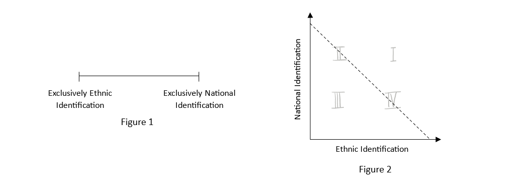

If ethnic and national identification are incompatible, all observations will cluster on the dashed diagonal in Figure 2. If, however, my hypothesis is correct, we will see significant spread around the diagonal and also find observations in the first and third quadrants.

### 5 Research Design

To estimate the relationship between ethnic identification and national identification, I will use the following regression model.

$$NationalID_i = \alpha + \beta_1 * EthnicID_i + \epsilon_i$$

In a second model, I will introduce an interaction term to examine whether the relationship between ethnic identification and national identification changes across different levels of perceived discrimination. I use z-scores for the regression.

$$NationalID_i = \alpha + \beta_1 * EthnicID_i + \beta_2 * Discrimination_i + \beta_3 * (EthnicID_i * Discrimination_i) + \epsilon_i$$

The assumption underlying this model is that discrimination could make it harder for students to identify with both their ethnicity and nationality at the same time. If a student feels like their ethnic group is discriminated against by other ethnic groups, they may perceive the two forms of identification to be mutually exclusive. In that case, they would have to choose between one and the other, and we would see a negative relationship between ethnic identification and national identification at high levels of perceived discrimination. Such patterns have been found, for example, among Latino college students in the US (Fuller-Rowell, Ong, and Phinney 2013).

Lastly, I will test if students at AAU develop dual identification through the mechanism of multiculturalism.

$$NationalID_i = \alpha + \beta_1 * EthnicID_i + \beta_2 * Multiculturalism_i + \epsilon_i$$

$Multiculturalism$ reflects the degree to which students believe that diverse communities are stronger than homogeneous communities are (see appendix for question wording). Again, I use z-scores for the regression. Priwati et al. (2021) find that in Indonesia, multiculturalism partially mediates the relationship between ethnic and national identification. This indicates that multiculturalism can foster dual identification in societies where diversity is an important aspect of national identity. For example, Indonesia’s national motto is ‘unity in diversity’. The dashed lines in Figure 3 below illustrate that relationship. If multiculturalism serves as a mediator in Ethiopia as well, it would be positively correlated with national identification when holding ethnic identification constant. Moreover, the relationship between the two forms of identification, represented by the solid line in Figure 3, would be less positive when controlling for multiculturalism than it is in the simple linear regression model.

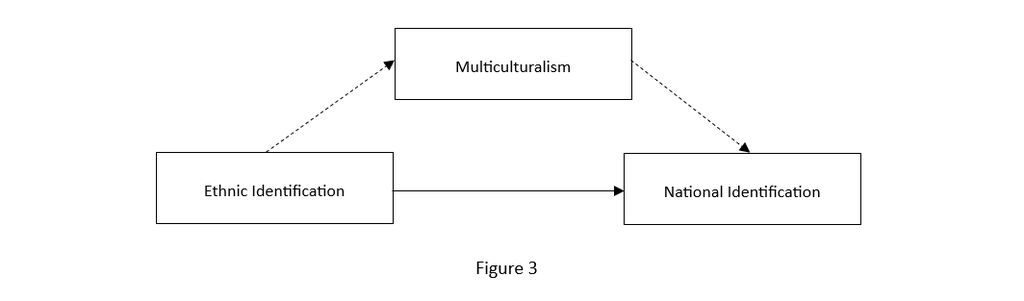

### 6 Research Context

The relationship between ethnic identification and national identification may vary substantially across countries. Still, Ethiopia appears to be a suitable context to test my hypothesis. While the Ethiopian people share some strong cultural traits, all major groups follow their own customs and traditions (Marcus, Crummey, and Mehretu 2024). Moreover, Ethiopia was in the midst of the civil war when the survey was conducted. The conflict between the Tigray region and the federal government had turned violent in November of 2020 - one and a half years before the first round of the survey. Hence, Ethiopia appears to be a very likely context to find a negative relationship between ethnic and national identification, if such a relationship exists anywhere. If there is no negative relationship between the two forms of identification in Ethiopia, we can be quite confident that there is no negative relationship in other countries either.

### 7 Results

#### **7.1 Sample Characteristics**

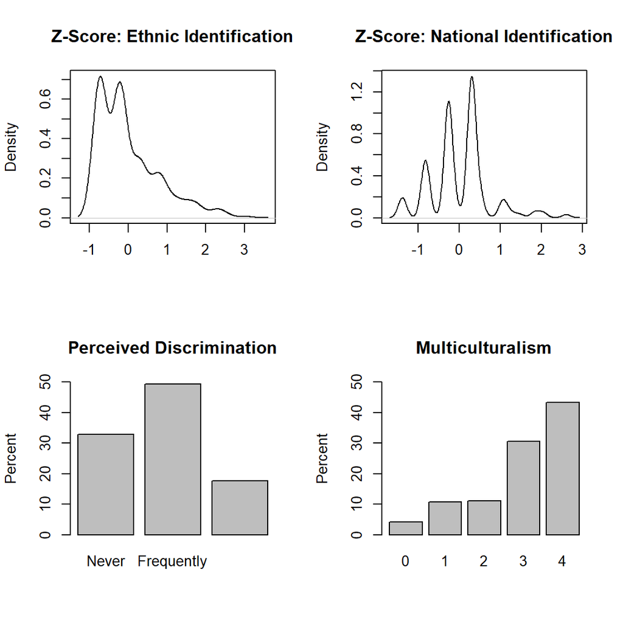

The bottom-left graph shows that nearly half of the students report frequent discrimination against their ethnic group, with approximately one third stating their group experiences no discrimination at all. Eighteen percent say their group faces constant discrimination. The bottom-right graph shows that the belief in multiculturalism is overall strong among the surveyed students. 43% of them strongly believe that diverse communities are stronger than homogeneous ones, and only 4% strongly believe that the opposite is true.

#### **7.2 Regression Analysis**

The graph below depicts ethnic and national identification among the students, along with the line of best fit resulting from simple linear regression.

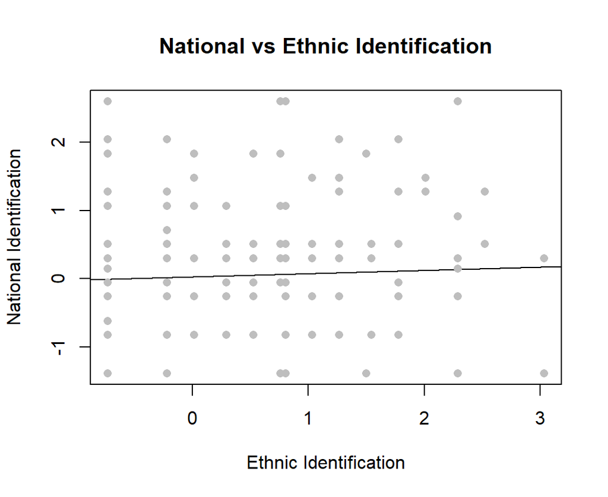

We can see observations in all four quadrants, and the regression line has a slightly positive slope, indicating that there is no negative correlation between the two forms of identification. This is in line with my hypothesis, and the regression outputs confirm those findings. The following table provides the summary of the three models outlined above.

|  | Bivariate | Interaction | Bivariate w/ Control |
| --- | --- | --- | --- |
| (Intercept) | 0.026 (0.032) | 0.014 (0.047) | 0.026 (0.031) |
| ethnicID | 0.049 (0.041) | 0.049 (0.059) | 0.053 (0.041) |
| discrimination |  | −0.088+ (0.050) |  |
| ethnicID × discrimination |  | 0.021 (0.058) |  |
| multiculturalism |  |  | 0.104*** (0.030) |
| Num.Obs. | 499 | 258 | 498 |
| R2 Adj. | 0.001 | 0.003 | 0.023 |

None of the three models show a significant negative correlation between national and ethnic identification. In contrast, the coefficients for $EthnicID$ are all positive, though not significant (0.049, 0.049, and 0.053).

In the second model, the coefficient for the interaction term $EthnicID * Discrimination$ is small and not statistically significant (0.021). This means that the relationship between ethnic identification and national identification does not significantly change across different levels of perceived discrimination. Regardless of whether students think their group is never, frequently, or always discriminated against, the relationship between ethnic and national identification is not negative.

### 8 Discussion and Implications

Overall, my findings indicate that there is no tradeoff between ethnic and national identification - even when students think that their ethnic group is discriminated against. A positive implication of this is that dual identification is possible and there is potential to achieve national identification even in diverse societies in which people strongly identify with their ethnicity. National identification, in turn, can improve state capacity and public good provision.

Given the positive correlation between national identification and multiculturalism, multiculturalism could serve as a strategy to foster dual identification in Ethiopia. National identification could be strengthened not just by promoting multiculturalism but also by consciously integrating it into the national identity. Admittedly, the conflict over Tigray makes it currently difficult to associate multiculturalism with Ethiopian identity. However, doing so could lead people who embrace multiculturalism to identify more strongly with their nationality, both due to their belief in the strength of diverse communities and due to ideological alignment with the national identity.

Yet, one key limitation of my analysis is that the sample, taken from college students at AAU, is not representative of the Ethiopian population as a whole. While Ethiopia is an unlikely case to find evidence in favor of my hypothesis, the student body of AAU is a likely test case within the nation. College students’ social identities differ from those of the wider population. For instance, college students may be better educated about and more involved in national politics, making them more likely to identify as Ethiopian. Hence, further research is necessary to test the external validity of my findings.

In terms of methodology, my findings suggest that the unidimensional model fails to adequately measure social identities. In particular, such a model cannot account for people who identify with both their ethnicity and their nationality. Even if the unidimensional model may be accurate in some contexts, we still need the bidimensional model to demonstrate the accuracy of the unidimensional one by showing that there is indeed a negative correlation between two forms of identification (Ryder, Alden, and Paulhus (2000)). Thus, if my hypothesis is valid for broader populations, we will need to reconsider the wording of survey questions designed to capture social identities and give respondents the opportunity to separately rank the strength of their ethnic and national identification.

### References

AfroBarometer. 2020. “Merged Round 7 Codebook (34 Countries).” https://www.afrobarometer.org/wp-content/uploads/2023/02/r7_merged.codebook_final_14dec20-1-1.pdf.

Berry, John W, Jean S Phinney, David L Sam, and Paul Vedder. 2006. *Immigrant Youth in Cultural Transition*. Mahwah, NJ: Erlbaum.

Campbell, John. 1999. “Nationalism, Ethnicity and Religion: Fundamental Conflicts and the Politics of Identity in Tanzania.” *Nations and Nationalism* 5 (1): 105–25.

Davis, Thomas C. 1999. “Revisiting Group Attachment: Ethnic and National Identity.” *Political Psychology* 20 (1): 25–47.

Fuller-Rowell, Thomas E, Anthony D Ong, and Jean S Phinney. 2013. “National Identity and Perceived Discrimination Predict Changes in Ethnic Identity Commitment: Evidence from a Longitudinal Study of Latino College Students.” *Applied Psychology* 62 (3): 406–26.

Marcus, Harold G., Donald Edward Crummey, and Assefa Mehretu. 2024. “Ethiopia.” Encyclopædia Britannica. https://www.britannica.com/place/Ethiopia.

Mengsteab, M., D. A. Dow, J. Springman, J. F. Tellez, S. Adamu, and F. Hailu. 2023. “Final Technical Report: The Effect of Social Ties on Engagement & Cohesion: Evidence from Ethiopian University Students.” IN: Long-term Assistance; Services for Research - Partners for University-Led Solutions Engine (LASER PULSE Consortium). https://pdf.usaid.gov/pdf_docs/PA021155.pdf.

Mulimbi, Bethany, and Sarah Dryden-Peterson. 2019. “Experiences of (Dis) Unity: Students’ Negotiation of Ethnic and National Identities in Botswana Schools.” *Anthropology & Education Quarterly* 50 (4): 404–23.

Priwati, Acintya Ratna, Adelia Krishna Putri, Valendra Granitha Shandika Puri, Annisa Ardi Ayuningtya, Wenty Marina Minza, and Kwartarini Wahyu Yuniarti. 2021. “Multiculturalism as a Mediator of Ethnic Identity and National Identity Among Javanese Adolescents.” *Makara Human Behavior Studies in Asia* 25 (1): 108–15.

Ryder, Andrew G, Lynn E Alden, and Delroy L Paulhus. 2000. “Is Acculturation Unidimensional or Bidimensional? A Head-to-Head Comparison in the Prediction of Personality, Self-Identity, and Adjustment.” *Journal of Personality and Social Psychology* 79 (1): 49.

### Appendix

**Ethnic Identity Index**

Now I am going to read out a list of groups that people join or attend. For each one, could you tell me whether you are a current official leader, an active member, an inactive member, or not a member. - A group of people that share the same ethnicity or culture and meet regularly to discuss or advance the interests of the group (Question 15_2).

Which of the following statements is closest to your view (Question 23)?

- Statement A: In Ethiopia, federal states should continue to be defined based on ethnic homelands.
- Statement B: In Ethiopia, federal states should change so that they are defined based on geographical features, not ethnic homelands.

**National Identity Index**

Ethiopians are very diverse. They come from different religions, ethnic groups, political parties, and economic and social backgrounds. Which of the following statements is closest to your view (Question 22)?

- Statement A: Overall, there is more that unites all Ethiopian as one people, than there is that divides them.
- Statement B: Overall, there is more that divides Ethiopian into different social and political groups, than there is that unites them as a single group.

Here is a list of actions that people sometimes take as citizens. For each of these, please tell me whether you have taken any of these actions during the past twelve months. - Contacted a government official to ask for help or make a complaint (Question 13_5).

**Perceived Discrimination (Interaction)**

Please tell me how often the following happens: - My ethnic group is discriminated against by members of other groups (Question 74_1).

**Multiculturalism (Mechanism)**

Which of the following statements is closest to your view (Question 20)?

- Statement A: Communities are stronger when they are made up of people from different ethnic groups, races, or religions.
- Statement B: Communities are stronger when they are made up of people who are similar to each other, that is, people from the same ethnic group, race, or religion.